# Statistical inference with the GSS data

## Setup

### Load packages

```r
library(ggplot2)
library(dplyr)
library(statsr)
```

### Load data

```r
load("gss.Rdata")
```

## Part 1: Data

The General Social Survey (GSS) is a sociological survey used to collect information and keep a historical record of the concerns, experiences, attitudes, and practices of residents of the United States.

The three main purposes of the GSS are :

- Gather data on contemporary American society in order to monitor and explain trends and constants in attitudes, behaviors, and attributes and examine the structure and functioning of society in general as well as the role played by relevant subgroups.
- Compare the United States to other societies in order to place American society in comparative perspective and develop cross-national models of human society.
- Make high-quality data easily accessible to scholars, students, policy makers, and others, with minimal cost and waiting.

The majority of the GSS data is obtained by face-to-face interviews by NORC at the University of Chicago, computer-assisted personal interviewing, and by telephone. The survey was conducted every year from 1972 to 1994 (except in 1979, 1981, and 1992). Since 1994, it has been conducted every other year. The survey takes about 90 minutes to administer. As of 2014, 30 national samples with 59599 respondents and more than 5900 variables have been collected.

### Sampling Design

The target population of the GSS is English and Spanish speaking adults (18+) living in households in the United States. The GSS sample is drawn using an area probability design that randomly selects respondents in households across the United States to take part in the survey. Respondents that become part of the GSS sample are from a mix of urban, suburban, and rural geographic areas. Participation in the study is strictly voluntary. However, because only about a few thousand respondents are interviewed in the main study, every respondent selected is very important to the results.

From 1975 to 2002 the GSS used full-probability sampling of households designed to give each household an equal probability of being included in the GSS. Hence, for household-level variables the GSS is self-weighting. Only one adult per household is interviewed, however, so persons living in large households have lower probabilities of selection. For person-level variables, weighting statistical results in proportion to the number of persons aged 18 or over in the household (variable ADULTS) can compensate for this. Beginning in 2004, the GSS began to use a two-stage sub-sampling design for nonresponse. Cases from which no response has been obtained after the initial stage of the field period are subsampled and resources are focused on gaining cooperation from this subset. Responses from persons in the subsample must subsequently be weighted up in order to represent all of those who had not responded by the time the subsample was drawn. Analysis of data from the 2004 and later GSSs should use weights WTSSALL, WTSS, or WTSSNR.

### Scope of Inference

From what is described in the points above, it seems pretty clear that the GSS survey is actually an observational retrospective study that uses a random sampling design to select a representative sample from U.S. residents.

However, potential bias may be introduced by nonresponse and weights are then used to correct this bias.

#### Generalizability

As it is, the GSS survey should be generalizable to all English and Spanish speaking adults (18 years of age and older) residing in the U.S.

#### Causality

As is well-known, making causal conclusions based on observational data is not recommended. Observational studies are only sufficient to show associations.

## Part 2: Research question

This analysis aims to answer the following research question : “Is there an association between the highest degree earned by U.S. residents (*degree* variable) and their inflation-adjusted family income in U.S. dollars (*coninc* variable) ?”.

Education, and to a lesser extent, the degree obtained are considered very important by many people to get decent earnings. However, it is not clear if the highest degree obtained is directly associated with the family income. That is the question this project will try to answer by using inference methods.

## Part 3: Exploratory data analysis

First of all, we need to create a subset of the *gss* dataset that only contains the *degree* and *coninc* variables and which is cleaned of any NA values.

```r
gss_degree_income <- gss %>% select(12, 27) %>% filter(coninc != "NA") %>% filter(degree != "NA")
```

### Highest degree obtained variable

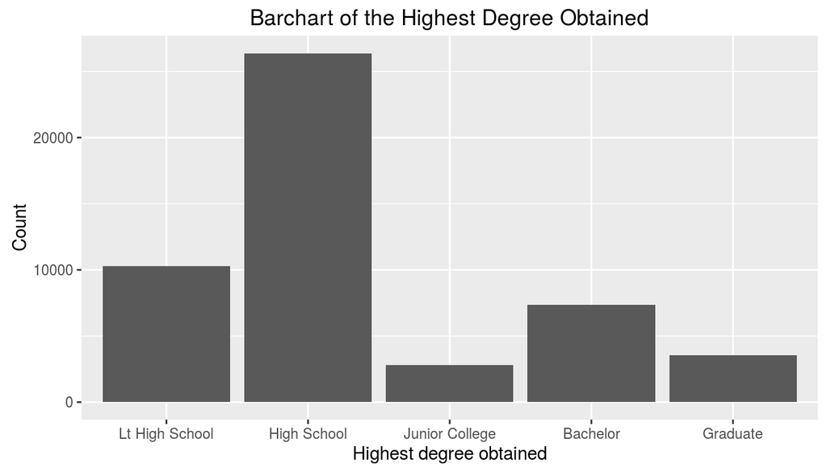

```r
ggplot(gss_degree_income, aes(x = degree)) + geom_bar() + xlab("Highest degree obtained") + ylab("Count") + ggtitle("Barchart of the Highest Degree Obtained")
```

```r
gss_degree_income %>% group_by(degree) %>% summarise (n = n()) %>% mutate(freq = n / sum(n)) %>% select(1, 3)
```

```
## Source: local data frame [5 x 2]
##
##           degree       freq
##           (fctr)      (dbl)
## 1 Lt High School 0.20375846
## 2    High School 0.52350525
## 3 Junior College 0.05564265
## 4       Bachelor 0.14632985
## 5       Graduate 0.07076380
```

As we may see, High School degree is the most prominent degree in our dataset, with more than 50% of the total number of observations.

### Total family income variable

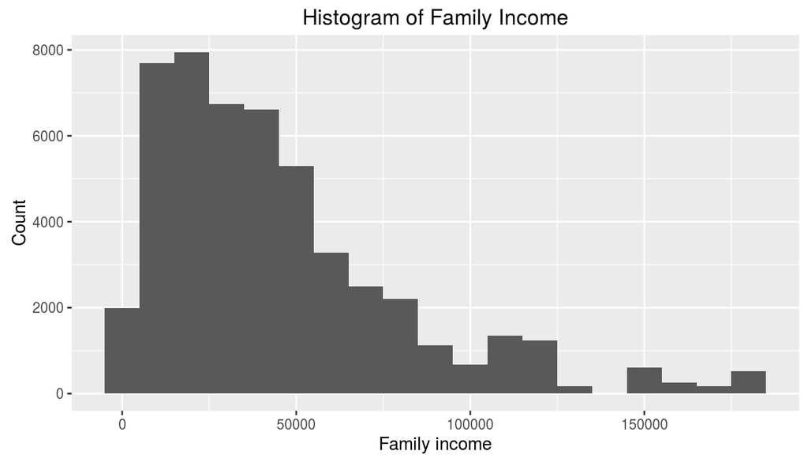

```r
ggplot(gss_degree_income, aes(x = coninc)) + geom_histogram(binwidth = 10000) + xlab("Family income") + ylab("Count") + ggtitle("Histogram of Family Income")
```

```r
gss_degree_income %>% summarise(mean_income = mean(coninc), sd_income = sd(coninc), min_income = min(coninc), max_income = max(coninc))
```

```
##   mean_income sd_income min_income max_income
## 1    44864.34  36019.59        383     180386
```

As we may see, the distribution of family income is right skewed and unimodal with clear high income outliers.

### Family income vs. degree obtained

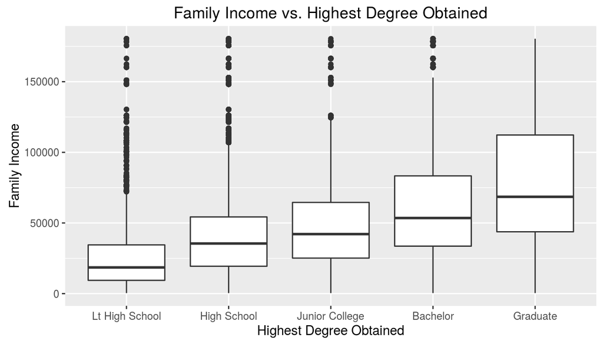

```r
ggplot(gss_degree_income, aes(x = degree, y = coninc)) + geom_boxplot() + xlab("Highest Degree Obtained") + ylab("Family Income") + ggtitle("Family Income vs. Highest Degree Obtained")
```

```r
gss_degree_income %>% group_by(degree) %>% summarise(median_by_group = median(coninc), iqr_by_group = IQR(coninc))
```

```
## Source: local data frame [5 x 3]
##
##           degree median_by_group iqr_by_group
##           (fctr)           (dbl)        (dbl)
## 1 Lt High School           18519        25090
## 2    High School           35471        34913
## 3 Junior College           42130        39398
## 4       Bachelor           53507        49748
## 5       Graduate           68516        68504
```

As we may see, there is a pretty clear association between the highest degree obtained and the total family income. However, the wider interquartile range in the college and above groups and the presence of outliers in the high school and below groups means that this relationship may not be as strong as it seems. So it remains to be confirmed that this relationship is actually statistically significant.

## Part 4: Inference

Here we wish to investigate if the relationship (observed above) between family income and degree obtained is actually significant.

To this end, we will test the null hypothesis $H_0$ that the mean family income is equal for all the highest degree groups (“Lt High School”, “High Schol”, “Junior College”, “Bachelor”, “Graduate”), against the alternative hypothesis $H_A$ that at least one pair of means is different.

More accurately we will test the hypothesis
$$H_0 : \mu_{LHS} = \mu_{HS} = \mu_{JC} = \mu_B = \mu_G,$$
against
$$H_A : \mbox{there are at least 2 group means that are significantly different from each other}.$$

The method we will use to test these hypotheses is the *analysis of variance (ANOVA)*. There are three conditions we must check for this type of analysis :

- All observations must be independent.
- The data in each group must be nearly normal.
- The variance within each group must be approximately equal.

### Conditions for ANOVA

#### Independance

As the data are a simple random sample from less than 10% of the total population, this condition is satisfied.

#### Near normality

To check normality we could use normal probability plots for each groups.

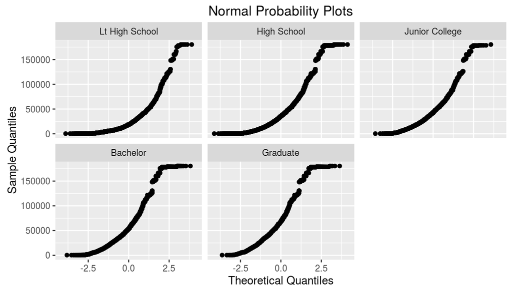

```r
ggplot(gss_degree_income, aes(sample = coninc)) + stat_qq() + facet_wrap(~ degree) + xlab("Theoretical Quantiles") + ylab("Sample Quantiles") + ggtitle("Normal Probability Plots")
```

As we may see, there is some deviation from normality, we should keep that in mind when we conclude our study.

#### Near constant variance

As we saw in the boxplots above, the total range and interquartile range of the groups are different, we should also keep that in mind when we conclude our study.

### Computations for ANOVA

```r
anova(lm(coninc ~ degree, data = gss_degree_income))
```

```
## Analysis of Variance Table
##
## Response: coninc
##              Df     Sum Sq    Mean Sq F value    Pr(>F)
## degree        4 1.0813e+13 2.7032e+12  2496.2 < 2.2e-16 ***
## Residuals 50388 5.4566e+13 1.0829e+09
## ---
## Signif. codes:  0 '***' 0.001 '**' 0.01 '*' 0.05 '.' 0.1 ' ' 1
```

The ANOVA table reports a $F$ statistic value of 2496 which measures the ratio of the average group and within group variabilities and a p-value of approximately 0.

In this context we may reject the null hypothesis $H_0$ and state that the average family income varies significantly across some groups. It still remains to be seen which groups have different means.

### Multiple comparisons

If we decided to use multiple two-sample $T$ test to compare the different means two by two, we would have an inflation of the Type 1 error rate. This issue is resolved by using a modified significance level with the Bonferroni correction.

```r
pairwise.t.test(gss_degree_income$coninc, gss_degree_income$degree, p.adjust.method = "bonferroni")
```

```
##
##  Pairwise comparisons using t tests with pooled SD
##
## data:  gss_degree_income$coninc and gss_degree_income$degree
##
##                Lt High School High School Junior College Bachelor
## High School    <2e-16         -           -              -
## Junior College <2e-16         <2e-16      -              -
## Bachelor       <2e-16         <2e-16      <2e-16         -
## Graduate       <2e-16         <2e-16      <2e-16         <2e-16
##
## P value adjustment method: bonferroni
```

### Conclusion

This study establishes an association between the highest degree earned by U.S. residents and their inflation-adjusted family income in U.S. dollars. Moreover, the mean family incomes of the different degree groups are significantly different from each other.

However, as we mentioned above, some of the conditions for ANOVA were not fully respected, and so we must consider these conclusions with appropriate caution.